# Part II - (Ford Gobike Data Explanatory)

## by (Daniel A. Oladele)

## Investigation Overview

In this investigation, I wanted to look at the characteristics of trip data that could be used to predict their duration. The main focus was on the: duration, age, start/end hours, start/end weekdays, user type, and gender.

## Dataset Overview

This document explores a dataset containing the trip data of the ford gobike approximately 183,412. This data set includes information about individual rides made in a bike-sharing system covering the greater San Francisco Bay area.

## (Distribution of Trip Durations)

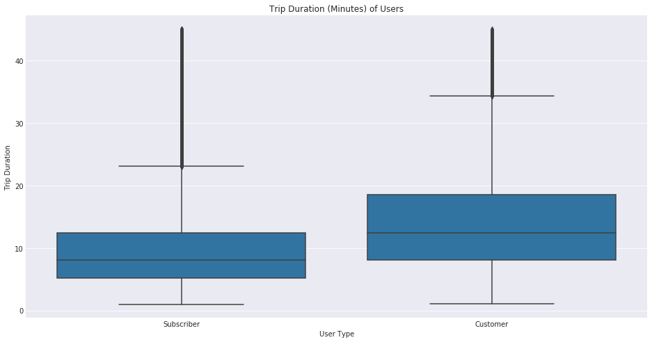

## (Distribution of days and hours)

Most active days were weekdays and Most active hours were an hour before or after a typical working day.

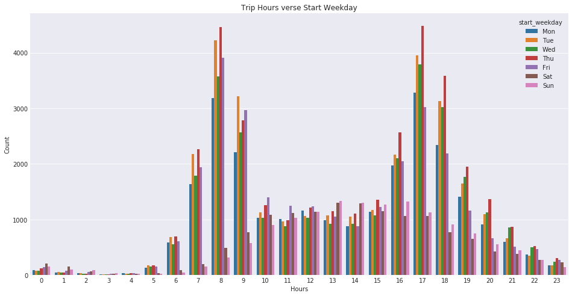

## (Distribution of User Age)

Age distribution was most concentrated between 22 to 45 years old.

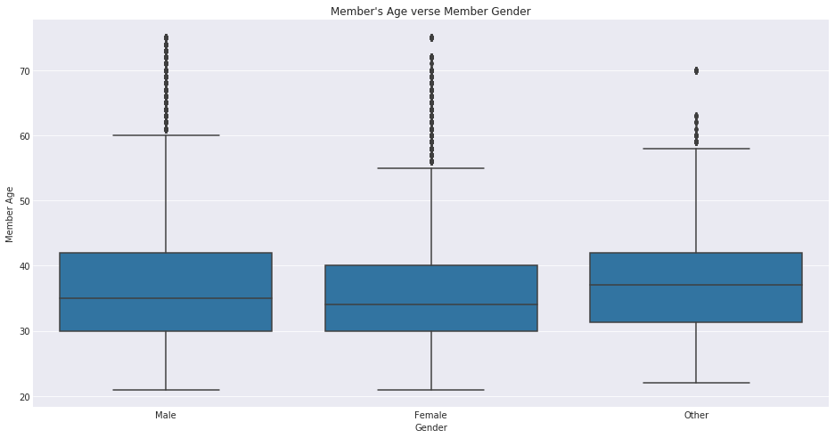

## (Distance Covered)

Interestingly, females on average spent more time on trips and covered more distance.

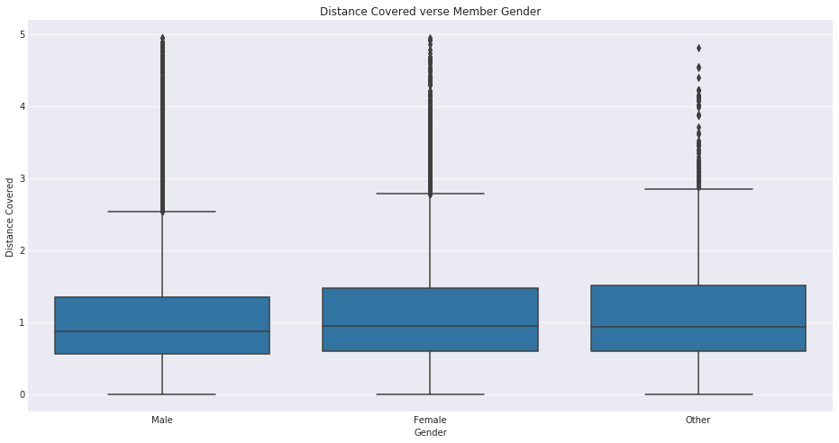

## (Bike Sharing)

No customer shared bikes on trips.

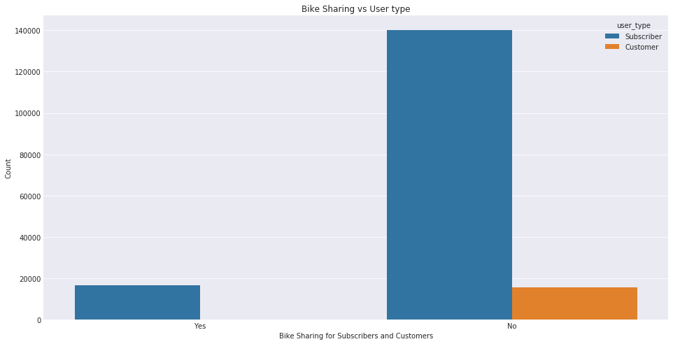

## (Distance Covered and Trip Duration)

There was a correlation between duration of trips and distance covered.

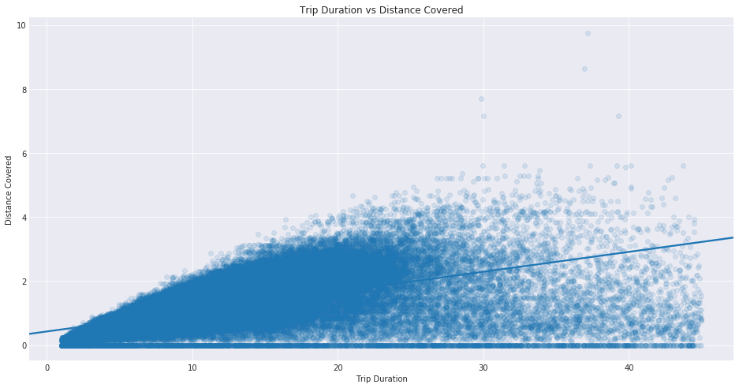